# Insecticide resistance management : prototype game scenarios

Andy South

2015-09-29

This document demonstrates how a few simple equations can simulate vector populations and insecticide resistance over time depending on the use of insecticides. Parameters within the simple equations can be modified to generate different patterns.

We intend to tweak the input parameters to generate reasonable scenarios. We are looking for assessment of the scenarios themselves rather than the input parameter values. The input parameters are simply a means by which we can generate reasonable scenarios.

In the following plots time is represented on the x axis, the top panel shows insecticide use, the middle panel shows vector population and the lower panel shows resistance (phenotypic). The code included e.g. `plot_sim(...)` is there merely to show us as developers how the scenarios were generated.

For an interactive version of the equations used to generate these plots see https://andysouth.shinyapps.io/shinyGame3.

## scenario 1 : no insecticide use

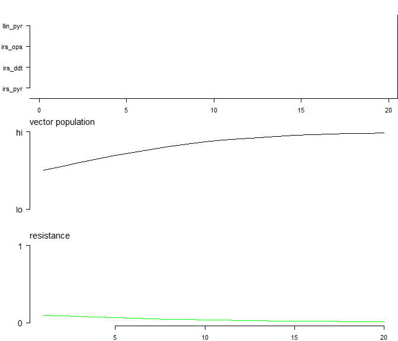

```r
plot_sim2( run_sim2() )
```

## scenario 2 : continuous pyr use in presence of resistance

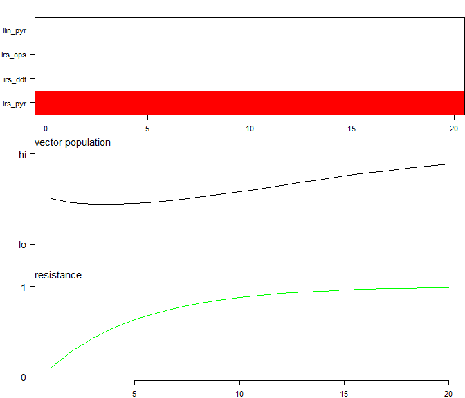

```r
l_config <- read_config()
l_config2 <- config_plan(l_config, t_strt=1, t_stop=20, control_id='irs_pyr')
plot_sim2( run_sim2(l_config=l_config2) )
```

## scenario 3 : continuous use of ops with no resistance

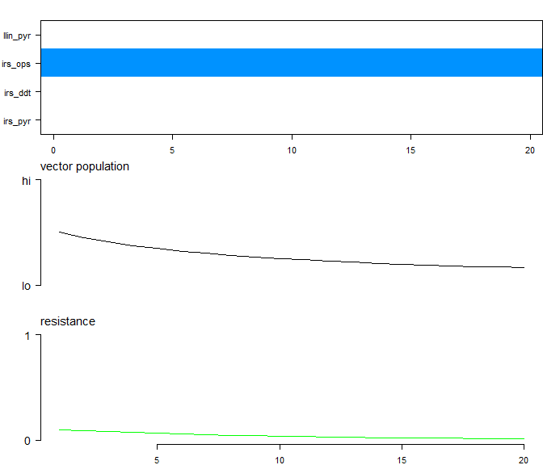

```r
l_config2 <- config_plan(l_config, t_strt=1, t_stop=20, control_id='irs_ops')
plot_sim2( run_sim2(l_config=l_config2) )
```

## scenario 4 : pyr used in alternate steps

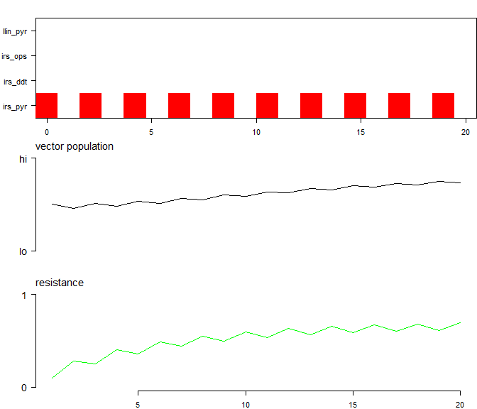

```r
l_config2 <- config_plan(l_config, t_strt=seq(1,20,2), t_stop=seq(1,20,2),
                            control_id='irs_pyr')
plot_sim2( run_sim2(l_config=l_config2) )
```

## scenario 5 : alternate use of ops and pyr

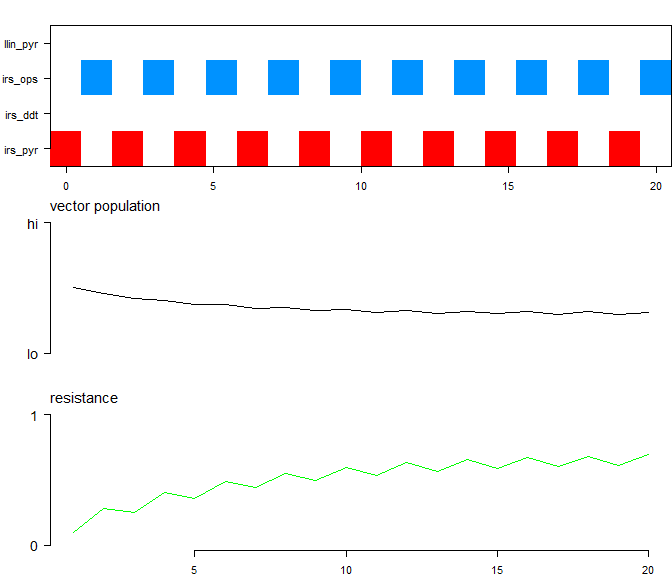

```r
l_config2 <- config_plan(l_config, t_strt=seq(1,20), t_stop=seq(1,20), control_id=c('irs_pyr','irs_ops'))
plot_sim2( run_sim2(l_config=l_config2) )
```

## scenario 6 : 10 steps pyr, 10 steps ops

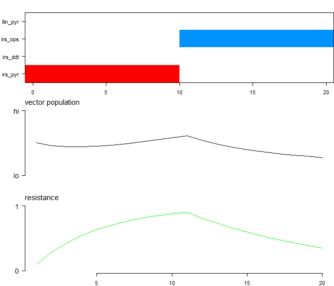

```r
l_config2 <- config_plan(l_config, t_strt=c(1,11), t_stop=c(10,20),
                            control_id=c('irs_pyr','irs_ops'))
plot_sim2( run_sim2(l_config=l_config2) )
```

## scenario 7 : 10 steps pyr, 10 steps ddt

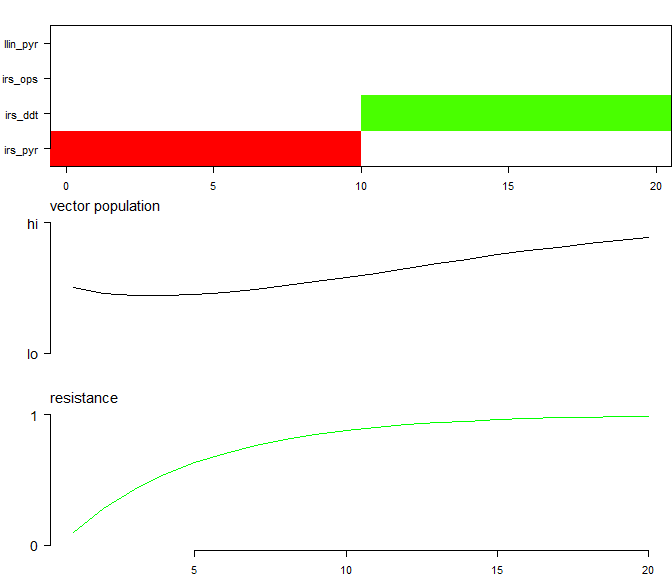

```r
l_config2 <- config_plan(l_config, t_strt=c(1,11), t_stop=c(10,20),
                            control_id=c('irs_pyr','irs_ddt'))
plot_sim2( run_sim2(l_config=l_config2) )
```

## scenario 8 : no insecticide use, 50% randomness added

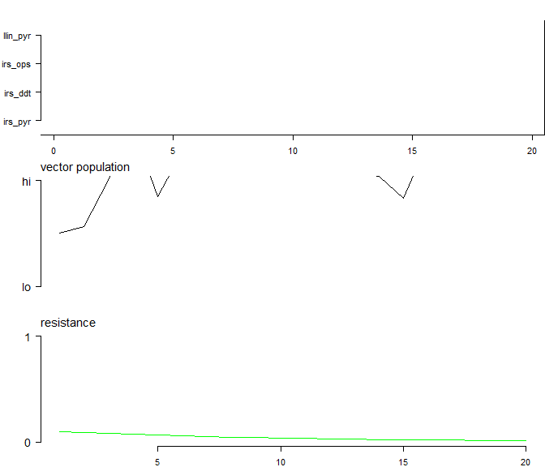

```r
plot_sim2( run_sim2(randomness=0.5) )
```

## scenario 9 : same as previous but just a different randomisation

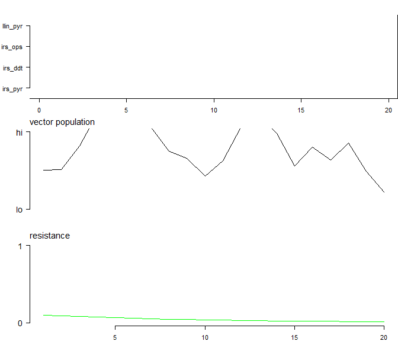

```r
plot_sim2( run_sim2(randomness=0.5) )
```

## scenario 10 : no insecticide use, 10% randomness added

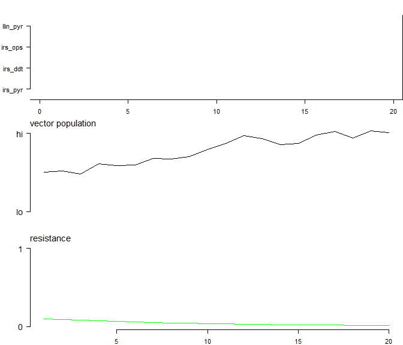

```r
plot_sim2( run_sim2(randomness=0.1) )
```

## scenario 11 : continuous pyr use, resistance_modifier < 1 decreases effect of resistance

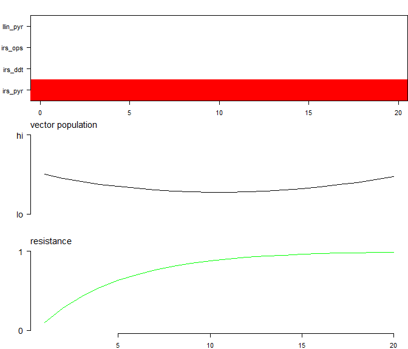

```r
l_config2 <- config_plan(l_config, t_strt=1, t_stop=20, control_id='irs_pyr')
plot_sim2( run_sim2(l_config=l_config2, resistance_modifier=0.1) )
```

## scenario 12 : continuous pyr use, resistance_modifier > 1 increases effect of resistance

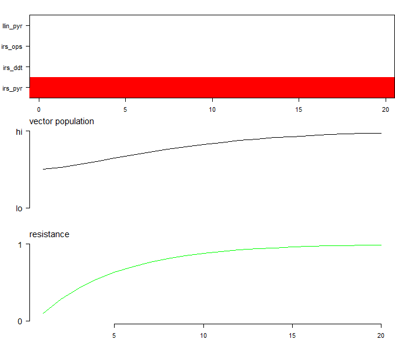

```r
plot_sim2( run_sim2(l_config=l_config2, resistance_modifier=10) )
```

## scenario 13 : set a different control and resistance mechanism and control plan

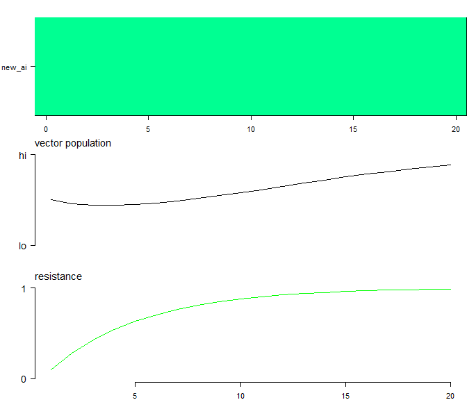

```r
l_config2 <- config_controls(l_config, control_id='new_ai', vector_id='an_gamb',
                             control_kill_rate=0.4)
l_config2 <- config_resistances(l_config2, control_id='new_ai', resistance_id="target_site",
                                resistance_strength=0.8,
                                resistance_incr=0.2,
                                resistance_decr=0.1)
l_config2 <- config_plan(l_config2, t_strt=1, t_stop=20, control_id='new_ai')
plot_sim2( run_sim2(l_config=l_config2) )
```

## scenario 14 : change carrying capacity over time (6 tstep(month) cycle). High growth rate.

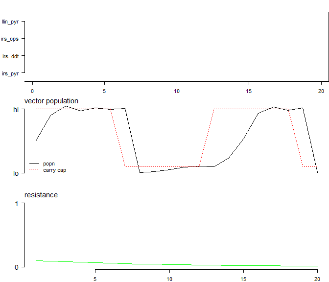

```r
carry_cap = c(rep(1,6),rep(0.1,6))
plot_sim2( run_sim2(carry_cap=carry_cap, rate_growth=1.6), plot_cc=TRUE )
```

## scenario 15 : carrying capacity gradual change. High growth rate.

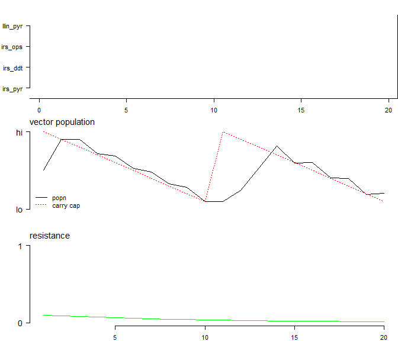

```r
carry_cap = seq(1,0.1,-0.1)
plot_sim2( run_sim2(carry_cap=carry_cap, rate_growth=1.6), plot_cc=TRUE )
```

## How controls and resistance mechanisms can be specified.

Our generic approach allows us to specify any combination of controls and resistance mechanisms. The controls cause a specified kill rate(s) on specified vector(s). The resistance mechanisms specify which controls they apply to and how fast resistance increases and decreases in the presence and absence respectively of that control. Cross resistance can be specified simply by specifiying multiple controls for one resistance mechanism.

The relationships between vectors, controls and resistance mechanisms are specified in simple configuration files. Here is a simple example of a collection of such configuration files :

#### vectors.csv

```
##   vector_id        vector_name vector_desc vector_growth
## 1   an_gamb  Anopheles gambiae          NA           0.4
```

#### controls.csv

```
##   control_id         control_name control_desc vector_id control_kill_rate
## 1    irs_pyr       IRS pyrethroid           NA   an_gamb               0.4
## 2    irs_ddt              IRS ddt           NA   an_gamb               0.5
## 3    irs_ops IRS organophosphates           NA   an_gamb               0.3
## 4   llin_pyr    pyrethroid bednet           NA   an_gamb               0.2
```

#### resistances.csv

```
##   resistance_id               resistance_name control_id
## 1   met_pyr_ddt metabolic pyrethroids and ddt    irs_pyr
## 2   met_pyr_ddt metabolic pyrethroids and ddt   llin_pyr
## 3   met_pyr_ddt metabolic pyrethroids and ddt    irs_ddt
##   resistance_strength resistance_incr resistance_decr
## 1                 1.0            0.20             0.1
## 2                 1.0            0.05             0.1
## 3                 0.9            0.20             0.1
```

#### control_plan.csv

```
##   t_strt t_stop control_id
## 1      1     10    irs_pyr
## 2     11     20    irs_ops
```